# IE 451 Homework 7

Author

Mustafa Mert Türkmen

## 8

### 8.a

```r
set.seed(42)
train <- sample(1: nrow(Carseats), nrow(Carseats)*3/4)
```

### 8.b

```r
tree.carseats <- tree(Sales ~ ., Carseats , subset = train)
summary(tree.carseats)
```

```
Regression tree:
tree(formula = Sales ~ ., data = Carseats, subset = train)
Variables actually used in tree construction:
[1] "ShelveLoc"   "Price"       "Age"         "Income"      "CompPrice"
[6] "Advertising"
Number of terminal nodes:  21
Residual mean deviance:  2.212 = 617.2 / 279
Distribution of residuals:
    Min.  1st Qu.   Median     Mean  3rd Qu.     Max.
-3.79600 -1.02400  0.05955  0.00000  0.98150  3.75500
```

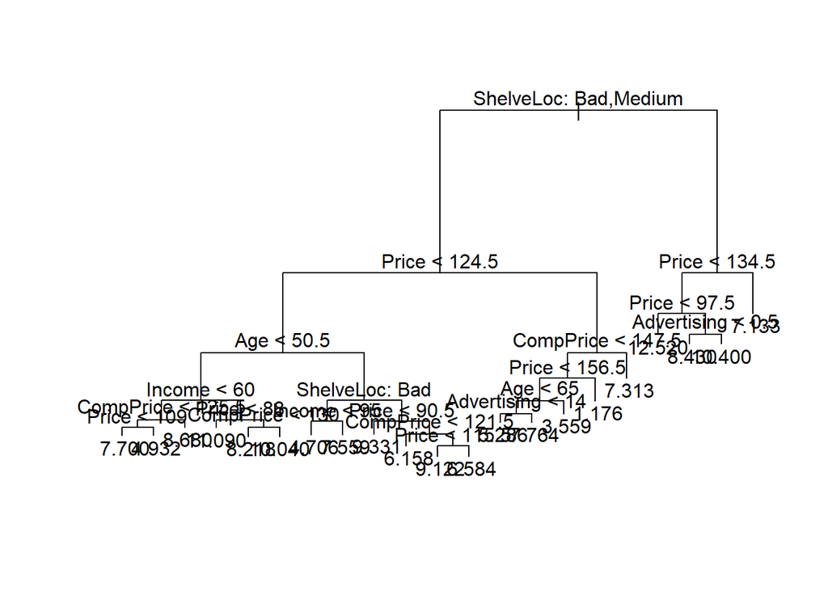

```r
plot(tree.carseats)
text(tree.carseats , pretty = 0)
```

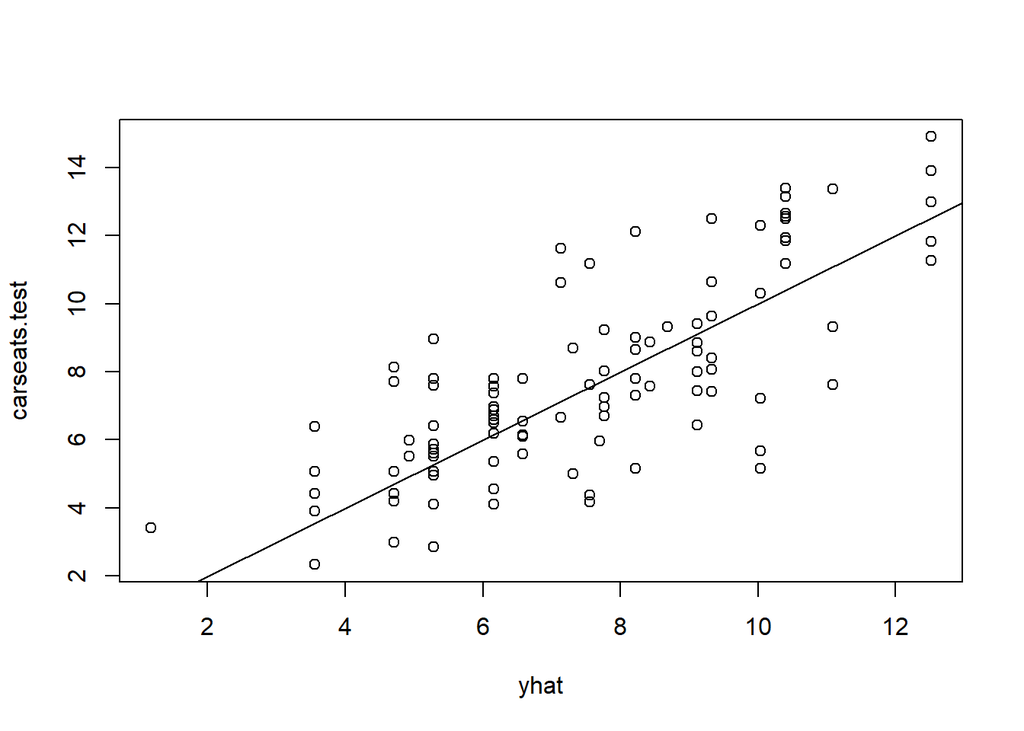

```r
yhat <- predict(tree.carseats , newdata = Carseats[-train , ])
carseats.test <- Carseats[-train, "Sales"]
plot(yhat , carseats.test)
abline (0, 1)
```

```r
MSE <- mean (( yhat - carseats.test)^2)
MSE
```

```
[1] 3.570511
```

```r
sqrt(MSE)
```

```
[1] 1.88958
```

- In other words, the test set MSE associated with the regression tree is 3.571. The square root of the MSE is therefore around 1.89, indicating that this model leads to test predictions that are (on average) within approximately 1.89 of the true sales value for the census tract.

### 8.c

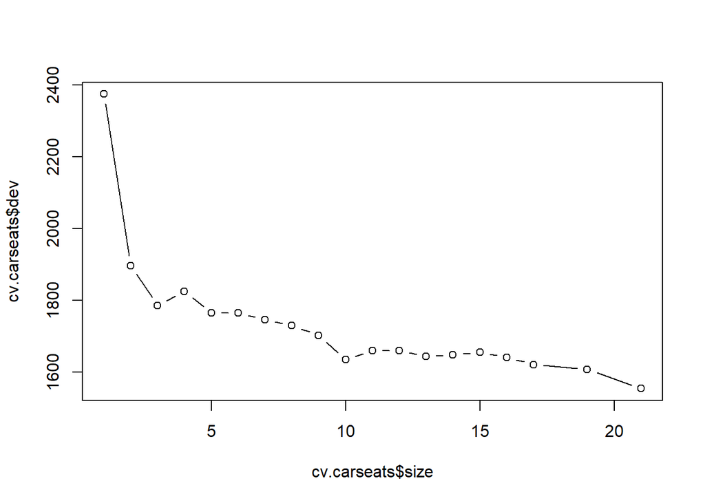

```r
cv.carseats <- cv.tree(tree.carseats)
plot(cv.carseats$size , cv.carseats$dev, type = "b")
```

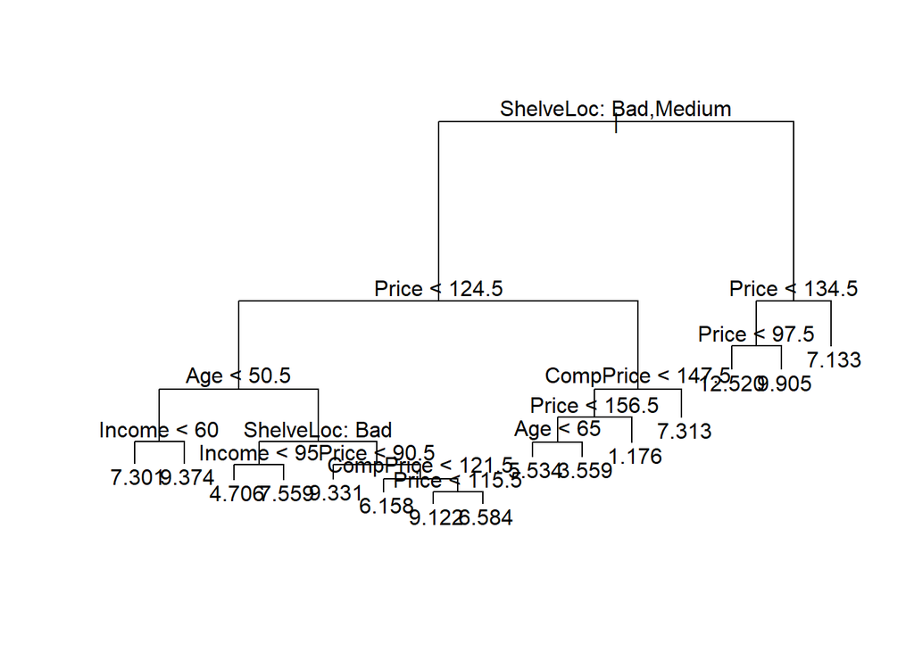

```r
prune.carseats <- prune.tree(tree.carseats , best = 15)
plot(prune.carseats)
text(prune.carseats , pretty = 0)
```

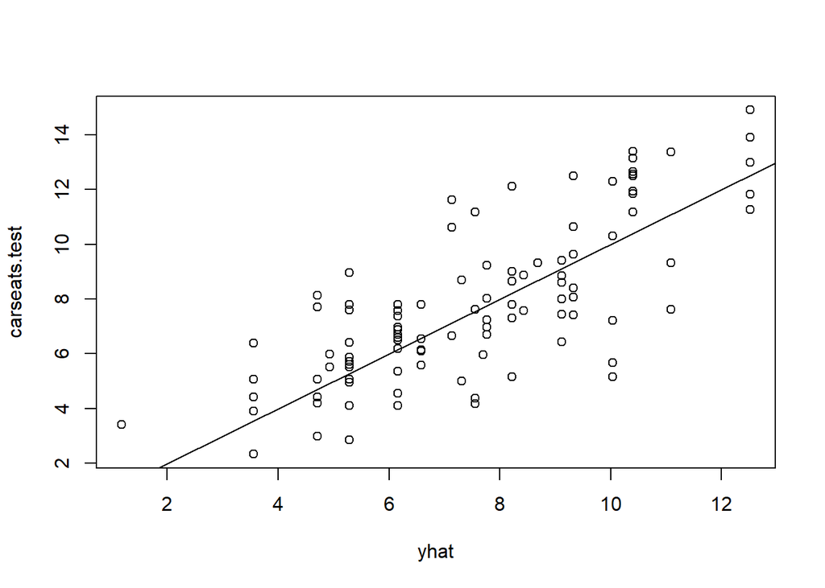

```r
yhat2 <- predict(prune.carseats , newdata = Carseats[-train , ])
carseats.test <- Carseats[-train, "Sales"]
plot(yhat , carseats.test)
abline (0, 1)
```

```r
MSE2 <- mean (( yhat2 - carseats.test)^2)
MSE2
```

```
[1] 4.0004
```

### 8.d

```r
set.seed (42)
bag.carseats <- randomForest(Sales ~ ., data = Carseats , subset = train , mtry = 10, importance = TRUE)
bag.carseats
```

```
Call:
 randomForest(formula = Sales ~ ., data = Carseats, mtry = 10,      importance = TRUE, subset = train)
               Type of random forest: regression
                     Number of trees: 500
No. of variables tried at each split: 10

          Mean of squared residuals: 2.560022
                    % Var explained: 67.47
```

```r
yhat.bag <- predict(bag.carseats , newdata = Carseats[-train , ])
MSE3 <- mean (( yhat.bag - carseats.test)^2)
MSE3
```

```
[1] 2.095133
```

- Bagging the tree improved the test MSE, we get lower mean square error.

```r
importance(bag.carseats)
```

```
               %IncMSE IncNodePurity
CompPrice   34.1142328    273.919168
Income      11.1554501    135.278866
Advertising 22.4232133    170.995462
Population   0.1389054     81.925141
Price       69.9247941    700.371286
ShelveLoc   73.1955099    624.662476
Age         21.1070008    241.787416
Education    2.1147323     60.963462
Urban        0.6279210      9.683275
US           2.2038258     10.704419
```

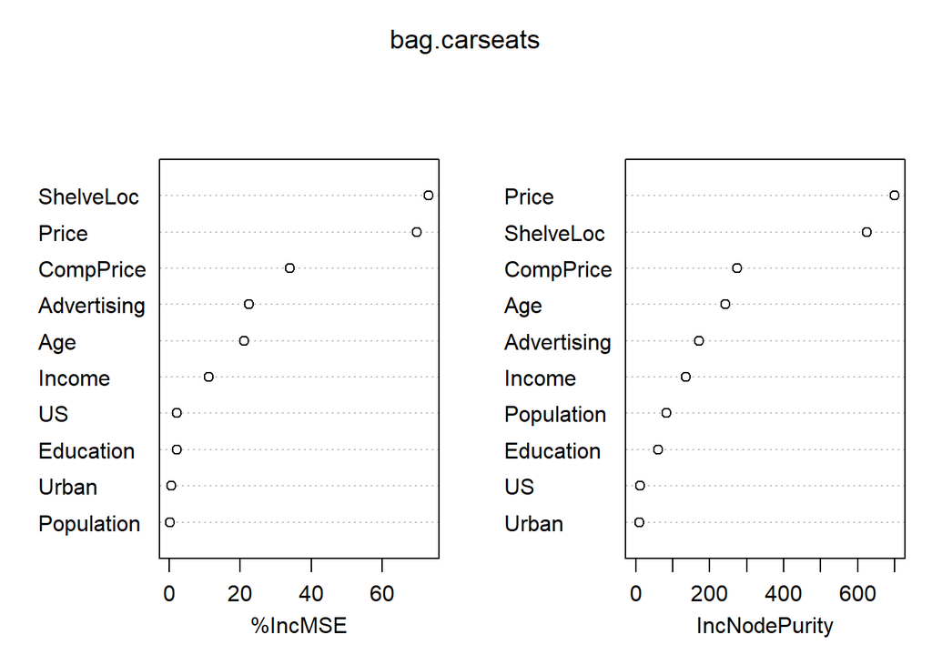

```r
varImpPlot(bag.carseats)
```

- Two most important variables are ShelveLoc and Price.

### 8.e

- From important variables plot, I can guess optimal number of variables sampled at each split might be equal to 6 so I will try it.

```r
set.seed(42)
rf.carseats <- randomForest(Sales ~ ., data = Carseats ,
subset = train , mtry = 6, importance=TRUE)
rf.carseats
```

```
Call:
 randomForest(formula = Sales ~ ., data = Carseats, mtry = 6,      importance = TRUE, subset = train)
               Type of random forest: regression
                     Number of trees: 500
No. of variables tried at each split: 6

          Mean of squared residuals: 2.634841
                    % Var explained: 66.51
```

```r
yhat.rf <- predict(rf.carseats , newdata = Carseats[-train , ])
MSE4 <- mean (( yhat.rf - carseats.test)^2)
MSE4
```

```
[1] 2.135175
```

- The test set MSE is 2.14; we obtain a higher test MSE than bagging (2.1).
- When we use 6 variables at each node in random forest, it does not seem to have an positive effect.

```r
importance(rf.carseats)
```

```
               %IncMSE IncNodePurity
CompPrice   25.2569120     248.45324
Income       8.3918721     148.73360
Advertising 18.8686387     192.82901
Population   1.0371840     102.29243
Price       58.2732106     644.17800
ShelveLoc   67.1960735     596.27785
Age         20.1744612     259.49350
Education    1.1858664      76.95389
Urban       -0.1386316      14.31795
US           4.5884943      17.04021
```

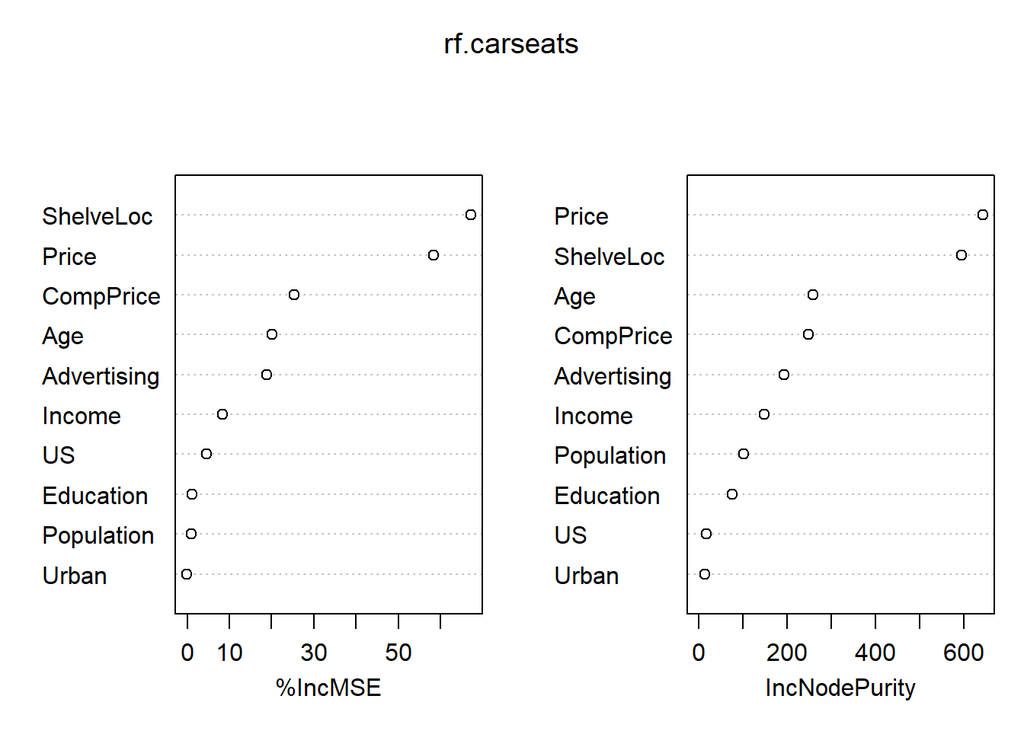

```r
varImpPlot(rf.carseats)
```

- ShelveLoc and Price are by far the two most important variables - the same important variables with bagging.

## Homework 5 Redo

```r
d <- read_csv("used-cars.csv", show_col_types = FALSE) %>%
  select(Price, Age_08_04, KM, Fuel_Type, HP, Met_Color, Automatic, CC, Doors, Quarterly_Tax, Weight) %>%
  rename(Age = Age_08_04,
         Fuel = Fuel_Type,
         Metallic = Met_Color,
         QuartTax = Quarterly_Tax) %>%
  mutate(Fuel = factor(Fuel),
         Metallic = factor(Metallic, levels = c(0,1), labels = c("No", "Yes")),
         Automatic = factor(Automatic, levels = c(0,1), labels = c("No", "Yes")),
         across(c(Doors, CC, HP, QuartTax), factor)
         )
```

```r
summary(d)
```

```
     Price            Age              KM             Fuel            HP
 Min.   : 4350   Min.   : 1.00   Min.   :     1   CNG   :  17   110    :835
 1st Qu.: 8450   1st Qu.:44.00   1st Qu.: 43000   Diesel: 155   86     :249
 Median : 9900   Median :61.00   Median : 63390   Petrol:1264   97     :164
 Mean   :10731   Mean   :55.95   Mean   : 68533                 72     : 73
 3rd Qu.:11950   3rd Qu.:70.00   3rd Qu.: 87021                 90     : 36
 Max.   :32500   Max.   :80.00   Max.   :243000                 69     : 34
                                                                (Other): 45
 Metallic  Automatic        CC      Doors      QuartTax       Weight
 No :467   No :1356   1600   :845   2:  2   85     :613   Min.   :1000
 Yes:969   Yes:  80   1300   :248   3:622   69     :559   1st Qu.:1040
                      1400   :164   4:138   185    : 96   Median :1070
                      2000   :119   5:674   19     : 72   Mean   :1072
                      1900   : 30           100    : 19   3rd Qu.:1085
                      1800   : 14           234    : 19   Max.   :1615
                      (Other): 16           (Other): 58
```

- I will investigate for any unfamiliar data in my dataset.

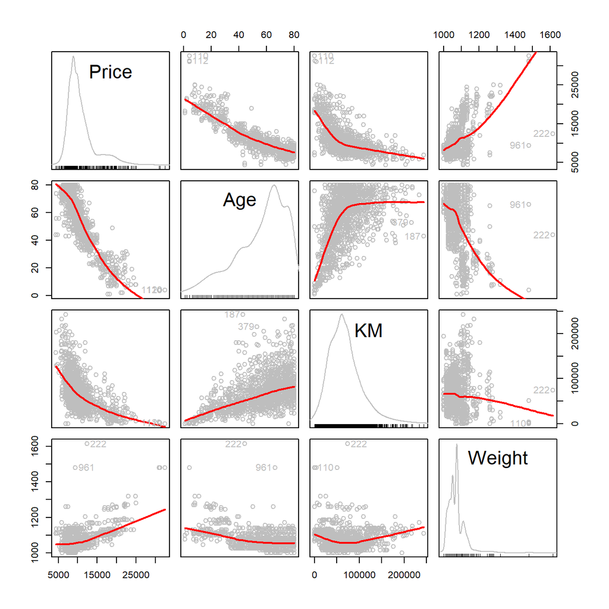

```r
scatterplotMatrix(~ Price + Age + KM + Weight, d, regLine = FALSE,
                  smooth = list(spread = FALSE, col.smooth = "red", lty.smooth = "solid"), col = "gray",
                  id = TRUE)
```

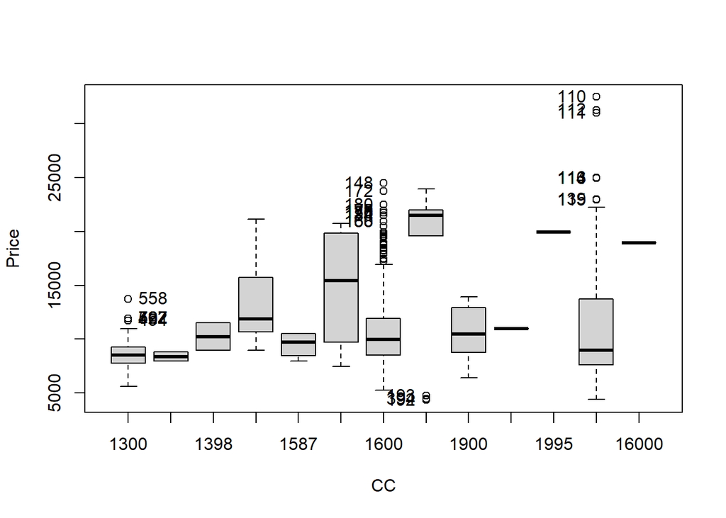

```
 [1] "462" "494" "522" "558" "797" "148" "172" "180" "175" "179" "126" "155"
[13] "184" "150" "168" "192" "193" "394" "110" "111" "112" "113" "114" "115"
[25] "116" "139"
```

```r
Boxplot(Price ~ CC, d)
```

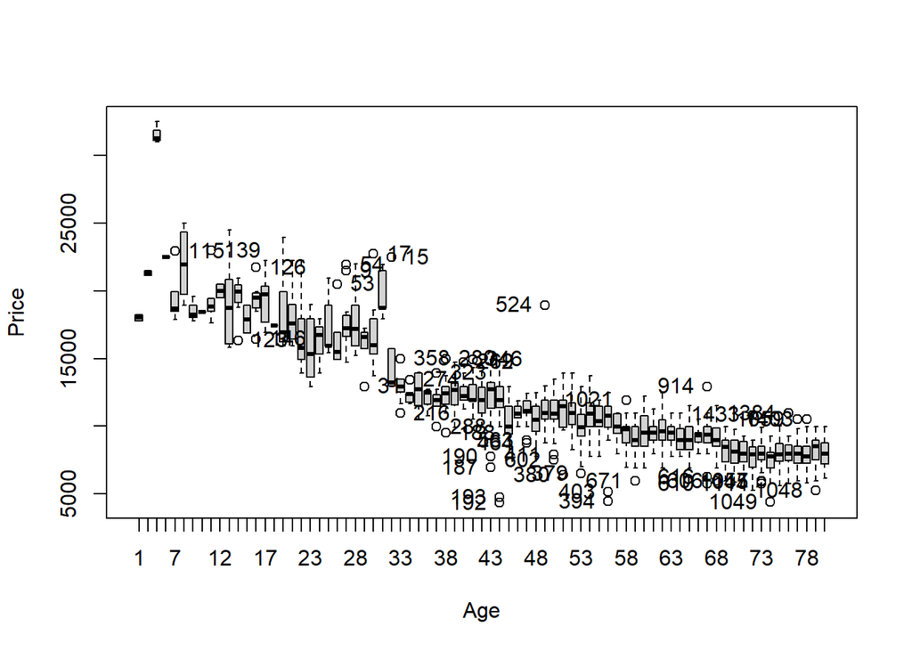

```
 [1] "115"  "139"  "123"  "146"  "126"  "53"   "9"    "54"   "31"   "17"
[11] "15"   "216"  "358"  "274"  "288"  "323"  "188"  "280"  "212"  "269"
[21] "346"  "187"  "190"  "192"  "193"  "464"  "563"  "524"  "411"  "602"
[31] "380"  "379"  "394"  "403"  "1021" "671"  "610"  "616"  "914"  "606"
[41] "1433" "1045" "1057" "1114" "1049" "1384" "1059" "1403" "1048"
```

```r
Boxplot(Price ~ Age, d)
```

- I will eliminate the 16000 CC value, it looks like an mistake and also try to group data which are close to each other to fit a better model.

```r
usedcars <- d %>%
  mutate( HP = fct_collapse(HP,
             `72` = c("69", "71", "72", "73"),
             `86` = c("86", "90"),
             `97`= c("97", "98"),
             `112` = c("107", "110", "116", "192")),
          CC = fct_collapse(CC,
              `1300` = c("1300", "1332"),
              `1400` = c("1398", "1400"),
              `1600`= c("1587",  "1598",  "1600", "16000"),
              `2000`= c("1800",  "1900",  "1975",  "1995",  "2000"))
          )
summary(usedcars)
```

```
     Price            Age              KM             Fuel        HP
 Min.   : 4350   Min.   : 1.00   Min.   :     1   CNG   :  17   72 :109
 1st Qu.: 8450   1st Qu.:44.00   1st Qu.: 43000   Diesel: 155   86 :285
 Median : 9900   Median :61.00   Median : 63390   Petrol:1264   97 :166
 Mean   :10731   Mean   :55.95   Mean   : 68533                 112:876
 3rd Qu.:11950   3rd Qu.:70.00   3rd Qu.: 87021
 Max.   :32500   Max.   :80.00   Max.   :243000

 Metallic  Automatic     CC      Doors      QuartTax       Weight
 No :467   No :1356   1300:250   2:  2   85     :613   Min.   :1000
 Yes:969   Yes:  80   1400:166   3:622   69     :559   1st Qu.:1040
                      1600:854   4:138   185    : 96   Median :1070
                      2000:166   5:674   19     : 72   Mean   :1072
                                         100    : 19   3rd Qu.:1085
                                         234    : 19   Max.   :1615
                                         (Other): 58
```

### 1

```r
set.seed (42)
train2 <- sample (1: nrow(usedcars), nrow(usedcars)*0.75)
tree.usedcars <- tree(Price ~ ., usedcars , subset = train2)
summary(tree.usedcars)
```

```
Regression tree:
tree(formula = Price ~ ., data = usedcars, subset = train2)
Variables actually used in tree construction:
[1] "Age"    "Weight" "HP"     "KM"
Number of terminal nodes:  8
Residual mean deviance:  1673000 = 1.789e+09 / 1069
Distribution of residuals:
   Min. 1st Qu.  Median    Mean 3rd Qu.    Max.
-5781.0  -729.9    18.5     0.0   670.1  8019.0
```

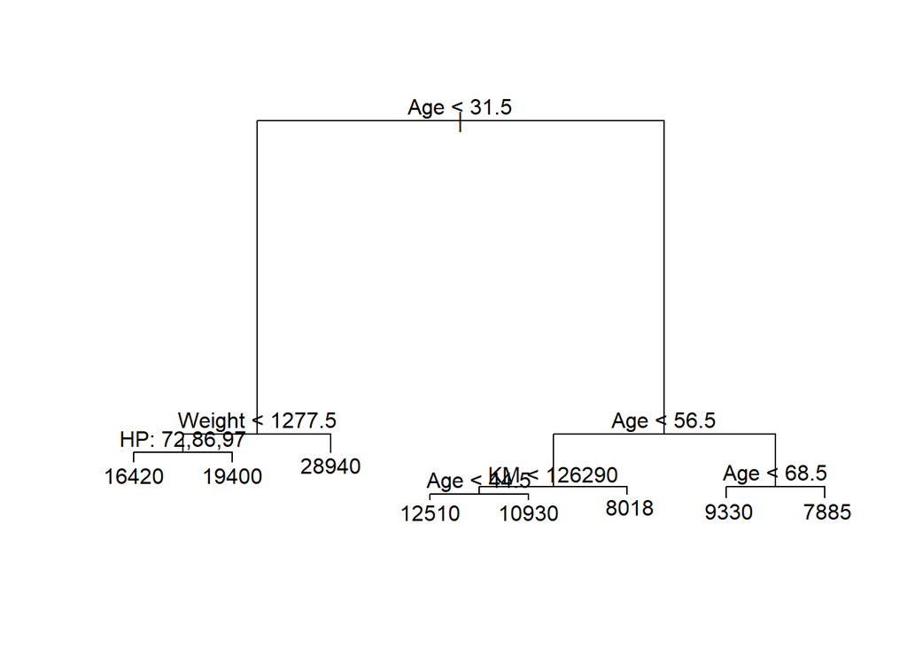

```r
plot(tree.usedcars)
text(tree.usedcars , pretty = 0)
```

```r
yhat3 <- predict(tree.usedcars , newdata = usedcars[-train2, ])
usedcars.test <- usedcars[-train2, "Price", -1]
MSE5 <- mean((yhat3 - usedcars.test)^2)
MSE5
```

```
[1] 2311362
```

```r
sqrt(MSE5)
```

```
[1] 1520.317
```

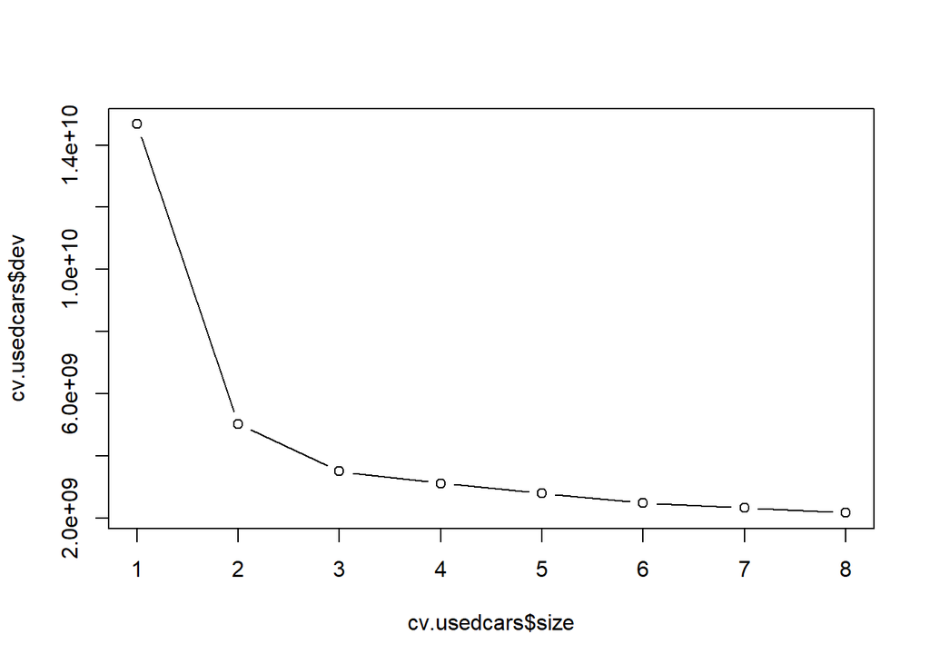

```r
cv.usedcars <- cv.tree(tree.usedcars)
plot(cv.usedcars$size , cv.usedcars$dev, type = "b")
```

- With looking this plot, I try to find the minimized deviance and it looked like on the size 8, so I cannot prune my tree, even if I did it will not reduce MSE.
- Lets try to fit best random forest model.

```r
set.seed (42)
bag.usedcars <- randomForest(Price ~ ., data = usedcars , subset = train2 , mtry = 10, importance = TRUE)
bag.usedcars
```

```
Call:
 randomForest(formula = Price ~ ., data = usedcars, mtry = 10,      importance = TRUE, subset = train2)
               Type of random forest: regression
                     Number of trees: 500
No. of variables tried at each split: 10

          Mean of squared residuals: 1278204
                    % Var explained: 90.59
```

```r
yhat.bag2 <- predict(bag.usedcars , newdata = usedcars[-train2 , ])
mean (( yhat.bag2 - usedcars.test)^2)
```

```
[1] 1086551
```

```r
set.seed (42)
rf.usedcars <- randomForest(Price ~ ., data = usedcars,
subset = train , mtry = 5, importance = TRUE)
yhat.rf2 <- predict(rf.usedcars, newdata = usedcars[-train2 , ])
mean (( yhat.rf2 - usedcars.test)^2)
```

```
[1] 3302657
```

- Bagging the tree improved the test MSE, we get lower mean square error. However indicating m value lower, increase our MSE, so I will use randomForest model with mtry value 10.

### 2

```r
prediction <- predict(
    tree.usedcars,
    newdata = data.frame(
      Age = mean(usedcars$Age),
      KM = mean(usedcars$KM),
      Fuel = as.factor(get_mode(usedcars$Fuel)),
      HP = as.factor(get_mode(usedcars$HP)),
      CC = as.factor(get_mode(usedcars$CC)),
      QuartTax = as.factor(get_mode(usedcars$QuartTax)),
      Weight = mean(usedcars$Weight),
      Metallic = as.factor(get_mode(usedcars$Metallic)),
      Doors = as.factor(get_mode(usedcars$Doors)),
      Automatic = as.factor(get_mode(usedcars$Automatic))
    )
)
prediction
```

```
      1
10931.5
```

- The prediction value of decision tree model is equal to 10931.5.

```r
newdata <- data.frame(
      Age = mean(usedcars$Age),
      KM = mean(usedcars$KM),
      Fuel = as.factor(get_mode(usedcars$Fuel)),
      HP = as.factor(get_mode(usedcars$HP)),
      CC = as.factor(get_mode(usedcars$CC)),
      QuartTax = as.factor(get_mode(usedcars$QuartTax)),
      Weight = mean(usedcars$Weight),
      Metallic = as.factor(get_mode(usedcars$Metallic)),
      Doors = as.factor(get_mode(usedcars$Doors)),
      Automatic = as.factor(get_mode(usedcars$Automatic))
    )
```

- prediction2 <- predict( bag.usedcars, newdata = newdata ) )
- I could not figure out my problem, I deeply look my newdata structure and bag.usedcars structure, and they looked as same to me. So, I could not show the predicted value of random forest.

### 3

```r
ctrl <- trainControl(method = "cv", number = 10)

lm_model <- train(Price ~ .+ Age:Fuel, data = usedcars, method = "lm", trControl = ctrl)
tree_model <- train(Price ~ . , data = usedcars, method = "rpart", trControl = ctrl)
rf_model <- train(Price ~ ., data = usedcars, method = "rf", trControl = ctrl)

resampling_results <- resamples(list(
  LM = lm_model,
  Tree = tree_model,
  RF = rf_model
))

summary(resampling_results)
```

```
Call:
summary.resamples(object = resampling_results)

Models: LM, Tree, RF
Number of resamples: 10

MAE
          Min.   1st Qu.    Median      Mean   3rd Qu.      Max. NA's
LM    812.2289  848.7756  902.5372  906.0583  955.0785 1031.0208    0
Tree 1100.6397 1188.4678 1272.1035 1267.3353 1307.9563 1523.2530    0
RF    725.6870  785.5360  813.2728  800.8524  829.8499  846.4087    0

RMSE
          Min.  1st Qu.   Median     Mean  3rd Qu.     Max. NA's
LM   1077.7751 1152.411 1206.684 1277.712 1285.240 1776.482    0
Tree 1410.9305 1603.943 1641.907 1729.259 1751.794 2377.635    0
RF    941.1868 1010.672 1047.391 1047.308 1087.431 1155.193    0

Rsquared
          Min.   1st Qu.    Median      Mean   3rd Qu.      Max. NA's
LM   0.7782190 0.8600863 0.8881493 0.8734600 0.9099547 0.9203510    0
Tree 0.7050922 0.7548261 0.7614761 0.7757745 0.8043194 0.8498220    0
RF   0.8997531 0.9143831 0.9201640 0.9168875 0.9242396 0.9253694    0
```